# Análise Exploratória dos Dados da base de dados de jogadores do FIFA 19

```python
import pandas as pd
import numpy as np
import matplotlib.pyplot as plt
import seaborn as sns

%matplotlib inline
```

```python
data=pd.read_csv('data.csv')
```

```python
data.head()
```

|  | Unnamed: 0 | ID | Name | Age | Photo | Nationality | Flag | Overall | Potential | Club | ... | Composure | Marking | StandingTackle | SlidingTackle | GKDiving | GKHandling | GKKicking | GKPositioning | GKReflexes | Release Clause |
| --- | --- | --- | --- | --- | --- | --- | --- | --- | --- | --- | --- | --- | --- | --- | --- | --- | --- | --- | --- | --- | --- |
| 0 | 0 | 158023 | L. Messi | 31 | https://cdn.sofifa.org/players/4/19/158023.png | Argentina | https://cdn.sofifa.org/flags/52.png | 94 | 94 | FC Barcelona | ... | 96.0 | 33.0 | 28.0 | 26.0 | 6.0 | 11.0 | 15.0 | 14.0 | 8.0 | €226.5M |
| 1 | 1 | 20801 | Cristiano Ronaldo | 33 | https://cdn.sofifa.org/players/4/19/20801.png | Portugal | https://cdn.sofifa.org/flags/38.png | 94 | 94 | Juventus | ... | 95.0 | 28.0 | 31.0 | 23.0 | 7.0 | 11.0 | 15.0 | 14.0 | 11.0 | €127.1M |
| 2 | 2 | 190871 | Neymar Jr | 26 | https://cdn.sofifa.org/players/4/19/190871.png | Brazil | https://cdn.sofifa.org/flags/54.png | 92 | 93 | Paris Saint-Germain | ... | 94.0 | 27.0 | 24.0 | 33.0 | 9.0 | 9.0 | 15.0 | 15.0 | 11.0 | €228.1M |
| 3 | 3 | 193080 | De Gea | 27 | https://cdn.sofifa.org/players/4/19/193080.png | Spain | https://cdn.sofifa.org/flags/45.png | 91 | 93 | Manchester United | ... | 68.0 | 15.0 | 21.0 | 13.0 | 90.0 | 85.0 | 87.0 | 88.0 | 94.0 | €138.6M |
| 4 | 4 | 192985 | K. De Bruyne | 27 | https://cdn.sofifa.org/players/4/19/192985.png | Belgium | https://cdn.sofifa.org/flags/7.png | 91 | 92 | Manchester City | ... | 88.0 | 68.0 | 58.0 | 51.0 | 15.0 | 13.0 | 5.0 | 10.0 | 13.0 | €196.4M |

5 rows × 89 columns

Inicialmente vamos contar os dados faltantes.

```python
data.isnull().sum()
```

```
Unnamed: 0                      0
ID                              0
Name                            0
Age                             0
Photo                           0
Nationality                     0
Flag                            0
Overall                         0
Potential                       0
Club                          241
Club Logo                       0
Value                           0
Wage                            0
Special                         0
Preferred Foot                 48
International Reputation       48
Weak Foot                      48
Skill Moves                    48
Work Rate                      48
Body Type                      48
Real Face                      48
Position                       60
Jersey Number                  60
Joined                       1553
Loaned From                 16943
Contract Valid Until          289
Height                         48
Weight                         48
LS                           2085
ST                           2085
                            ...
Dribbling                      48
Curve                          48
FKAccuracy                     48
LongPassing                    48
BallControl                    48
Acceleration                   48
SprintSpeed                    48
Agility                        48
Reactions                      48
Balance                        48
ShotPower                      48
Jumping                        48
Stamina                        48
Strength                       48
LongShots                      48
Aggression                     48
Interceptions                  48
Positioning                    48
Vision                         48
Penalties                      48
Composure                      48
Marking                        48
StandingTackle                 48
SlidingTackle                  48
GKDiving                       48
GKHandling                     48
GKKicking                      48
GKPositioning                  48
GKReflexes                     48
Release Clause               1564
Length: 89, dtype: int64
```

```python
data1=data.sort_values('Age')
data1.head()
```

|  | Unnamed: 0 | ID | Name | Age | Photo | Nationality | Flag | Overall | Potential | Club | ... | Composure | Marking | StandingTackle | SlidingTackle | GKDiving | GKHandling | GKKicking | GKPositioning | GKReflexes | Release Clause |
| --- | --- | --- | --- | --- | --- | --- | --- | --- | --- | --- | --- | --- | --- | --- | --- | --- | --- | --- | --- | --- | --- |
| 18206 | 18206 | 246269 | G. Nugent | 16 | https://cdn.sofifa.org/players/4/19/246269.png | England | https://cdn.sofifa.org/flags/14.png | 46 | 66 | Tranmere Rovers | ... | 43.0 | 40.0 | 43.0 | 50.0 | 10.0 | 15.0 | 9.0 | 12.0 | 9.0 | €165K |
| 17743 | 17743 | 244752 | J. Olstad | 16 | https://cdn.sofifa.org/players/4/19/244752.png | Norway | https://cdn.sofifa.org/flags/36.png | 52 | 69 | Sarpsborg 08 FF | ... | 42.0 | 13.0 | 19.0 | 20.0 | 7.0 | 8.0 | 9.0 | 11.0 | 8.0 | €188K |
| 13293 | 13293 | 246594 | H. Massengo | 16 | https://cdn.sofifa.org/players/4/19/246594.png | France | https://cdn.sofifa.org/flags/18.png | 62 | 75 | AS Monaco | ... | 50.0 | 52.0 | 62.0 | 65.0 | 8.0 | 14.0 | 12.0 | 9.0 | 15.0 | €1.1M |
| 16081 | 16081 | 241552 | J. Italiano | 16 | https://cdn.sofifa.org/players/4/19/241552.png | Australia | https://cdn.sofifa.org/flags/195.png | 58 | 79 | Perth Glory | ... | 57.0 | 36.0 | 38.0 | 43.0 | 7.0 | 7.0 | 9.0 | 10.0 | 5.0 | €630K |
| 18166 | 18166 | 243621 | N. Ayéva | 16 | https://cdn.sofifa.org/players/4/19/243621.png | Sweden | https://cdn.sofifa.org/flags/46.png | 48 | 72 | Örebro SK | ... | 44.0 | 14.0 | 19.0 | 16.0 | 10.0 | 9.0 | 8.0 | 7.0 | 6.0 | €158K |

5 rows × 89 columns

Agora vamos analisar a distribuição de número de jogadores pela idade, pelo overall e pelo potencial.

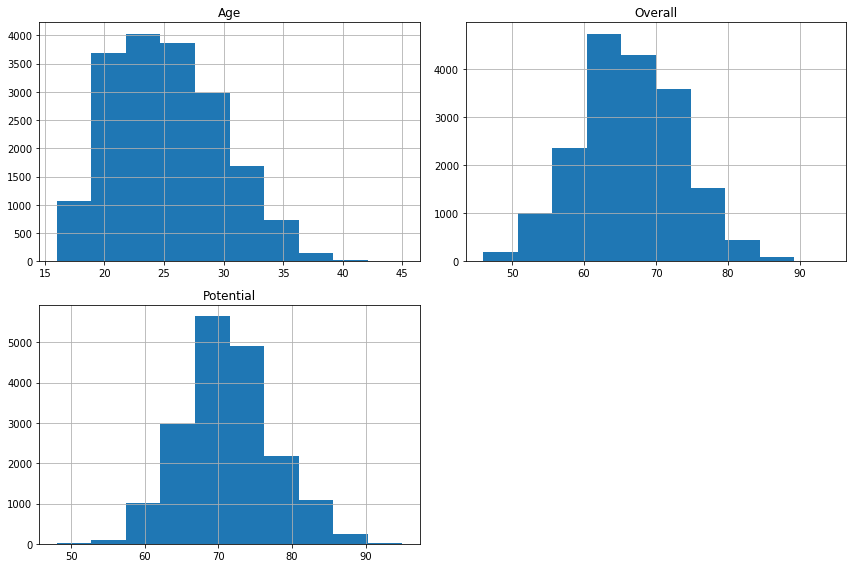

```python
data[['Overall', 'Age', 'Potential']].hist(figsize=(12,8))
plt.tight_layout()
```

Podemos perceber que a grande maioria dos jogadores têm entre 20 e 30 anos como esperado, têm overall entre 60 e 75, e que o potencial é concentrado entre 67 e 77.

Agora vamos separar os jogadores de acordo com a posição primária.

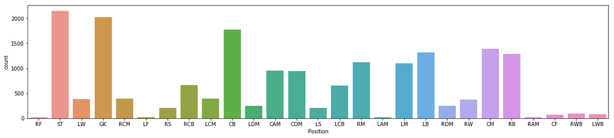

```python
plt.figure(figsize=(20,4))
sns.countplot('Position', data=data)
```

Podemos perceber que há mais atacantes e goleiros, seguidos pelos zagueiros, laterais e meias centrais.

Vamos analisar também a quantidade de jogadores de acordo com o pé preferido.

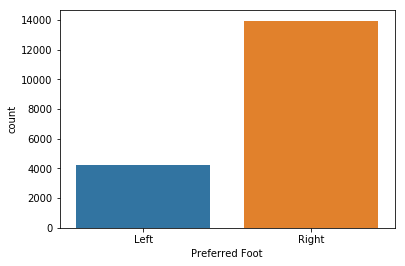

```python
sns.countplot('Preferred Foot', data=data)
```

Vamos analisar a quantidade de canhotos e destros por posição.

```python
data.groupby(['Position','Preferred Foot'])['Preferred Foot'].count()
```

```
Position  Preferred Foot
CAM       Left               256
          Right              702
CB        Left               341
          Right             1437
CDM       Left               126
          Right              822
CF        Left                18
          Right               56
CM        Left               249
          Right             1145
GK        Left               206
          Right             1819
LAM       Left                 9
          Right               12
LB        Left              1163
          Right              159
LCB       Left               264
          Right              384
LCM       Left                97
          Right              298
LDM       Left                49
          Right              194
LF        Left                 3
          Right               12
LM        Left               412
          Right              683
LS        Left                33
          Right              174
LW        Left               109
          Right              272
LWB       Left                66
          Right               12
RAM       Left                 9
          Right               12
RB        Left                14
          Right             1277
RCB       Left                32
          Right              630
RCM       Left                41
          Right              350
RDM       Left                23
          Right              225
RF        Left                 6
          Right               10
RM        Left               252
          Right              872
RS        Left                37
          Right              166
RW        Left                97
          Right              273
RWB       Left                 4
          Right               83
ST        Left               293
          Right             1859
Name: Preferred Foot, dtype: int64
```

Podemos perceber que as únicas posições que têm mais canhotos que destros são as de lateral esquerdo e ala esquerdo.

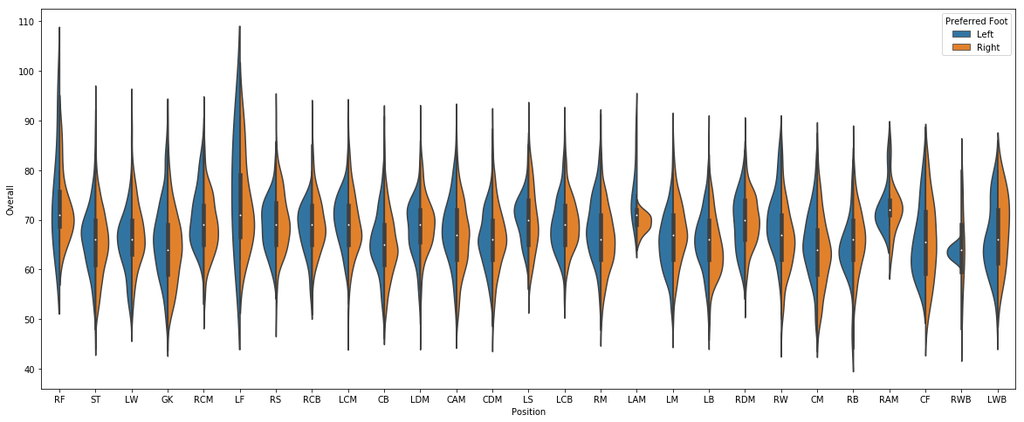

```python
plt.figure(figsize=(20,8))
sns.violinplot('Position', 'Overall', hue='Preferred Foot', data=data, split=True)
plt.show()
```

Percebemos também, que para as posições ao lado esquerdo do campo que têm maioria de destros os canhotos tendem a ser mais habilidosos, com exceção da posição de meia esquerdo. Já para as posições de maioria de canhotos, inusitadamente a posição de ala esquerdo tem os jogadores destros como mais habilidosos.

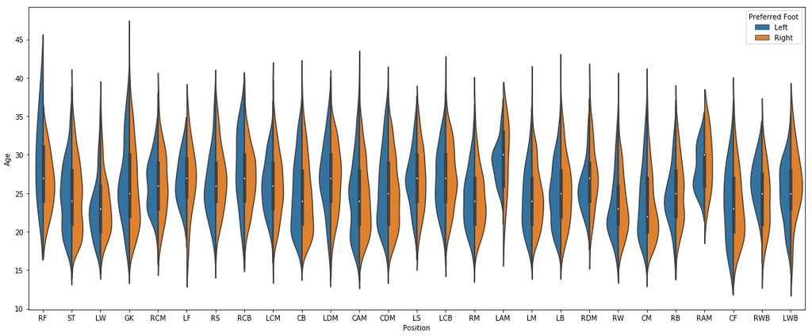

```python
plt.figure(figsize=(20,8))
sns.violinplot('Position', 'Age', hue='Preferred Foot', data=data,split=True)
plt.show()
```

Quanto à idade, é aproximadamente a proporção de destros e canhotos por posição.

Agora vamos transformar o valor dos jogadores em números para podermos fazer análises.

```python
def first_and_last(x):
    return (x[0], x[-1])

units = df['Value'].apply(first_and_last)
set(units)
```

```
{('€', '0'), ('€', 'K'), ('€', 'M')}
```

```python
def change_money(x):
    if x[-1] == '0':
        return int(x[1:])
    elif x[-1] == 'K':
        return 1000*float(x[1:-1])
    else:
        return 1000000*float(x[1:-1])
```

```python
data['Value'] = data['Value'].apply(change_money)
```

```python
data['Value'].min(), data['Value'].max()
```

```
(0.0, 118500000.0)
```

```python
df = data.copy()

df.sort_values(by='Value', ascending=False)[['Name', 'Club', 'Nationality', 'Age', 'Value', 'Overall']].iloc[:10]
```

|  | Name | Club | Nationality | Age | Value | Overall |
| --- | --- | --- | --- | --- | --- | --- |
| 2 | Neymar Jr | Paris Saint-Germain | Brazil | 26 | 118500000.0 | 92 |
| 0 | L. Messi | FC Barcelona | Argentina | 31 | 110500000.0 | 94 |
| 4 | K. De Bruyne | Manchester City | Belgium | 27 | 102000000.0 | 91 |
| 5 | E. Hazard | Chelsea | Belgium | 27 | 93000000.0 | 91 |
| 15 | P. Dybala | Juventus | Argentina | 24 | 89000000.0 | 89 |
| 16 | H. Kane | Tottenham Hotspur | England | 24 | 83500000.0 | 89 |
| 25 | K. Mbappé | Paris Saint-Germain | France | 19 | 81000000.0 | 88 |
| 7 | L. Suárez | FC Barcelona | Uruguay | 31 | 80000000.0 | 91 |
| 17 | A. Griezmann | Atlético Madrid | France | 27 | 78000000.0 | 89 |
| 10 | R. Lewandowski | FC Bayern München | Poland | 29 | 77000000.0 | 90 |

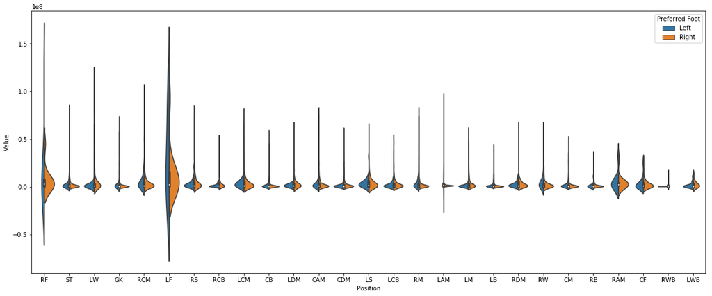

```python
plt.figure(figsize=(20,8))
sns.violinplot('Position', 'Value', hue='Preferred Foot', data=data, split=True)
plt.show()
```

É possível perceber que jogadores de ataque tendem a ser mais caros e os de defesa (principalmente laterais) tendem a ser mais baratos.